# Weight Lifting Exercises Prediction Assignment

E Danesh

21/07/2018

# Introduction

The objective of this project is to use data from accelerometers on the belt, forearm, arm, and dumbell of 6 participants who were asked to perform barbell lifts correctly and incorrectly in 5 different ways. A model is built based on selected features from the data to predict the correct excercise (class A) and common mistakes (class B,C,D and E).

More information is available from the website here: http://web.archive.org/web/20161224072740/http:/groupware.les.inf.puc-rio.br/har (see the section on the Weight Lifting Exercise Dataset).

## 1. Training data

after downloading traning data set (csv format), load it in R. The training data for this project are available here: https://d396qusza40orc.cloudfront.net/predmachlearn/pml-training.csv

```r
#Data were read in 2 data frames
training_data <- read.csv("pml-training.csv")
dim(training_data)
```

```
## [1] 19622   160
```

## 2. Selecting features

training_data consists of 160 variables and 19622 observations. Based on the codebook, variable names prefixed with “kurtosis_”, “skewness_”, “max_”, “min_”, “amplitude_”, “var_”, “avg_”, and “stddev_”, correspond to summary statistics calculated from the raw data at a measurement boundary. These are very sparse and/or contain very high proportions of missing values and/or “#DIV/0!” error values. Rather than impute for missing and error values, raw sensor data was used to build the model.

```r
varnames <- colnames(training_data)
selected_cols <- grep("^(roll)|^(pitch)|^(yaw)|^(gyros)|^(accel)|^(magnet)|^(classe)", varnames)

#only keep selected columns
training <- training_data[,selected_cols]
training$classe <- factor(training$classe)
```

## 3. Data slicing

training data was in turn divided in to train and test datasets to build and verify the model.

```r
#loading caret library
library(caret)
set.seed(669)
inTrain = createDataPartition(training$classe , p = 3/4)[[1]]
train = training[ inTrain,]
test = training[-inTrain,]
```

## 4. Random forests

Random forests was chosen to build the predictiopn model since it’s one of the most widely used and highly accurate methods for prediction. I acknowledge that this method is relatively slow (it took 1 hour and half on my system to build the model!). However, the accuracy is high (~0.99)

```r
modfit_rf <- train(classe ~ . , data = train, method="rf")
print(modfit_rf)
```

```
## Random Forest
##
## 14718 samples
##    48 predictor
##     5 classes: 'A', 'B', 'C', 'D', 'E'
##
## No pre-processing
## Resampling: Bootstrapped (25 reps)
## Summary of sample sizes: 14718, 14718, 14718, 14718, 14718, 14718, ...
## Resampling results across tuning parameters:
##
##   mtry  Accuracy   Kappa
##    2    0.9891760  0.9863112
##   25    0.9894185  0.9866186
##   48    0.9783795  0.9726584
##
## Accuracy was used to select the optimal model using the largest value.
## The final value used for the model was mtry = 25.
```

## 5. Prediction

The final model was used to predict excercise classes in the test data set. Then, a confusion matrix was build.

```r
pred_rf <- predict(modfit_rf, test)
t_rf <- table(pred_rf, test$classe)
confusionMatrix(t_rf)
```

```
## Confusion Matrix and Statistics
##
##
## pred_rf    A    B    C    D    E
##       A 1393   11    0    0    0
##       B    1  933    8    0    1
##       C    0    5  845    7    2
##       D    0    0    2  796    1
##       E    1    0    0    1  897
##
## Overall Statistics
##
##                Accuracy : 0.9918
##                  95% CI : (0.9889, 0.9942)
##     No Information Rate : 0.2845
##     P-Value [Acc > NIR] : < 2.2e-16
##
##                   Kappa : 0.9897
##  Mcnemar's Test P-Value : NA
##
## Statistics by Class:
##
##                      Class: A Class: B Class: C Class: D Class: E
## Sensitivity            0.9986   0.9831   0.9883   0.9900   0.9956
## Specificity            0.9969   0.9975   0.9965   0.9993   0.9995
## Pos Pred Value         0.9922   0.9894   0.9837   0.9962   0.9978
## Neg Pred Value         0.9994   0.9960   0.9975   0.9981   0.9990
## Prevalence             0.2845   0.1935   0.1743   0.1639   0.1837
## Detection Rate         0.2841   0.1903   0.1723   0.1623   0.1829
## Detection Prevalence   0.2863   0.1923   0.1752   0.1629   0.1833
## Balanced Accuracy      0.9977   0.9903   0.9924   0.9947   0.9975
```

## 6. Visualisation

rf variable importance table is shown below:

```r
varImp(modfit_rf)
```

```
## rf variable importance
##
##   only 20 most important variables shown (out of 48)
##
##                   Overall
## roll_belt          100.00
## pitch_forearm       61.79
## yaw_belt            55.48
## pitch_belt          47.26
## magnet_dumbbell_y   46.20
## magnet_dumbbell_z   46.18
## roll_forearm        44.84
## accel_dumbbell_y    27.50
## accel_forearm_x     18.04
## magnet_dumbbell_x   18.02
## roll_dumbbell       18.02
## magnet_belt_z       17.87
## accel_dumbbell_z    15.22
## accel_belt_z        14.86
## magnet_belt_y       13.71
## magnet_forearm_z    13.70
## gyros_belt_z        11.32
## yaw_arm             10.82
## magnet_belt_x       10.61
## roll_arm             9.30
```

roll_belt and pitch_forearm appear to be the two most important variable in our rf model. Therefore, we use them to visualise the “correctness” of the model in predicting excercise classes in the test dataset.

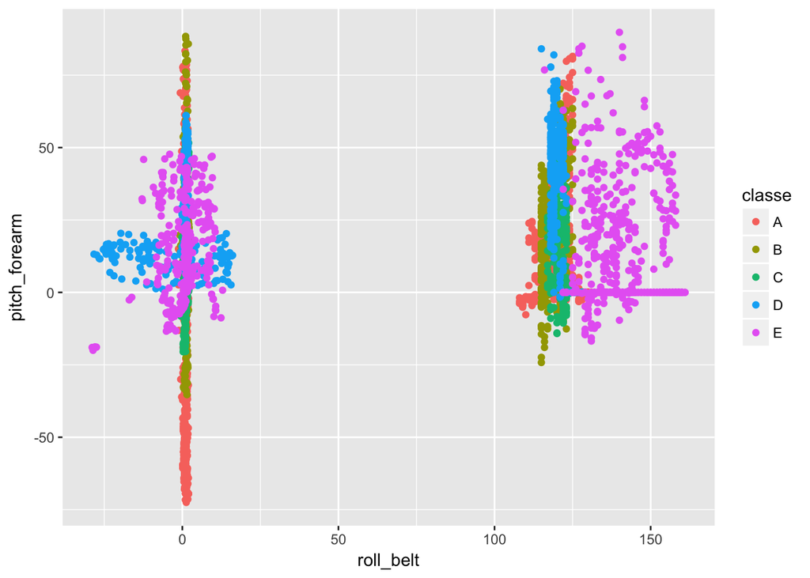

Figure 1. test data set

```r
p1 <-  qplot(roll_belt, pitch_forearm, col=classe, data=test)
p1
```

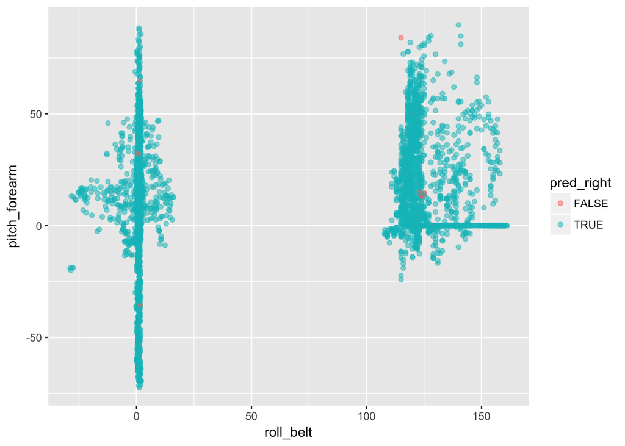

Figure 2. visualising correctly classified and miss-classified observations by the random forests model

```r
test$pred_right <- pred_rf == test$classe
p2 <- qplot(roll_belt, pitch_forearm, col=pred_right, alpha=I(1/2), data=test)
p2
```

In Fig.1, each data point represents an observation in the test data set, and each colour corresponds to one of the 5 classes. As can be seen in Fig.2, there are only a few observations miss-classified (coloured red).

# References

Velloso, E.; Bulling, A.; Gellersen, H.; Ugulino, W.; Fuks, H. Qualitative Activity Recognition of Weight Lifting Exercises. Proceedings of 4th International Conference in Cooperation with SIGCHI (Augmented Human ’13) . Stuttgart, Germany: ACM SIGCHI, 2013.